# DoshiYesha

**DECISION TREE**

```python
print(CutomerChurnData.columns)
```

```
Index(['tenure', 'age', 'address', 'income', 'employ', 'reside', 'longmon',
       'tollmon', 'equipmon', 'cardmon',
       ...
       'internet_Y', 'callid_Y', 'callwait_Y', 'forward_Y', 'confer_Y',
       'ebill_Y', 'custcat_C2', 'custcat_C3', 'custcat_C4', 'churn_Y'],
      dtype='object', length=1043)
```

```python
from sklearn.model_selection import train_test_split

# Adjusting for the encoded churn column name
X = CutomerChurnData.drop(['churn_Y'], axis=1)
y = CutomerChurnData['churn_Y']

# Splitting the dataset into training (0.7) and testing (0.3) sets
X_train, X_test, y_train, y_test = train_test_split(X, y, test_size=0.3, random_state=42)
```

```python
from sklearn.tree import DecisionTreeClassifier
model_DT = DecisionTreeClassifier(criterion="entropy", random_state=1, max_depth=3)
model_DT.fit(X_train, y_train)
predictions = model_DT.predict(X_test)
```

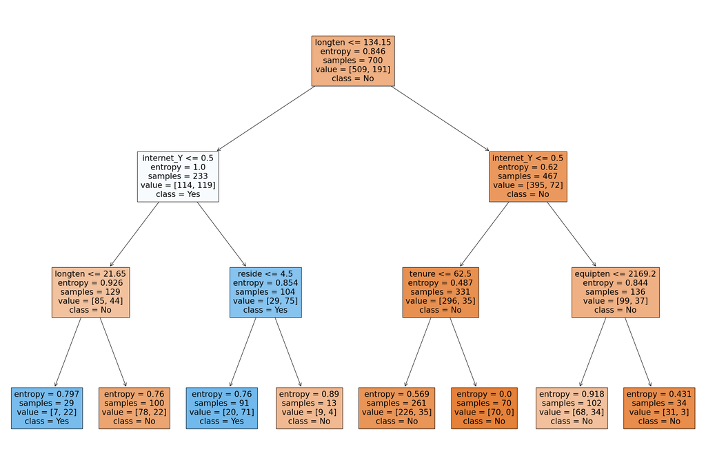

```python
import matplotlib.pyplot as plt
from sklearn import tree
feature_names = list(X_train.columns)
fig = plt.figure(figsize=(30,20))
_ = tree.plot_tree(model_DT,
                   feature_names=feature_names,
                   class_names=['No','Yes'],
                   filled=True)
plt.show()
```

```python
#print decision tree in text
print(tree.export_text(model_DT, feature_names=list(X_train.columns)))
```

```
|--- longten <= 134.15
|   |--- internet_Y <= 0.50
|   |   |--- longten <= 21.65
|   |   |   |--- class: 1
|   |   |--- longten >  21.65
|   |   |   |--- class: 0
|   |--- internet_Y >  0.50
|   |   |--- reside <= 4.50
|   |   |   |--- class: 1
|   |   |--- reside >  4.50
|   |   |   |--- class: 0
|--- longten >  134.15
|   |--- internet_Y <= 0.50
|   |   |--- tenure <= 62.50
|   |   |   |--- class: 0
|   |   |--- tenure >  62.50
|   |   |   |--- class: 0
|   |--- internet_Y >  0.50
|   |   |--- equipten <= 2169.20
|   |   |   |--- class: 0
|   |   |--- equipten >  2169.20
|   |   |   |--- class: 0
```

**CONFUSION MATRIX**

```python
#prediction on test data
prediction_on_test_DT = model_DT.predict(X_test)
```

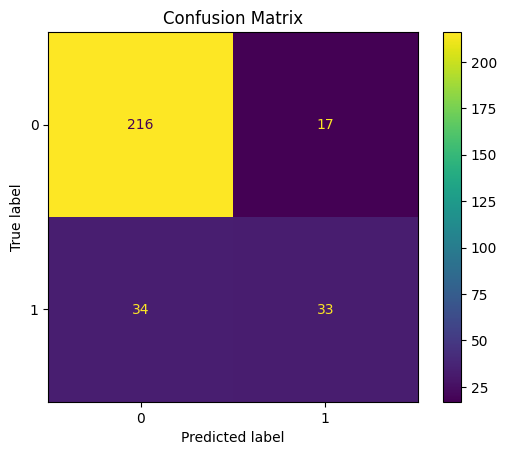

```python
from sklearn.metrics import confusion_matrix, ConfusionMatrixDisplay
cm_DT = confusion_matrix(y_test, prediction_on_test_DT)
ConfusionMatrixDisplay(confusion_matrix=cm_DT, display_labels=model_DT.classes_).plot()
plt.title('Confusion Matrix')
plt.show()
```

**PERFORMANCE DISCUSSION**

```python
from sklearn.metrics import classification_report
print(classification_report(y_test, prediction_on_test_DT))
```

```
              precision    recall  f1-score   support

           0       0.86      0.93      0.89       233
           1       0.66      0.49      0.56        67

    accuracy                           0.83       300
   macro avg       0.76      0.71      0.73       300
weighted avg       0.82      0.83      0.82       300
```

**Conclusion:**

Evaluation metrics provided detailed insights into model performance, guiding actionable interventions to address turnover drivers.

**Discussion:**

While effective in identifying non-churned customers, the model showed limitations in predicting churn accurately.

Actionable strategies, such as improving customer service and optimizing loyalty programs, can be derived from the analysis of key drivers.

**Limitations:**

Further exploration of advanced algorithms and techniques may enhance predictive accuracy and adaptability to evolving consumer behaviors.

```python
!jupyter nbconvert --to html "/content/drive/MyDrive/DoshiYesha.ipynb"
```

[output not shown]

[output cut: 133 more lines]

[output not shown]